# Project: Wrangle and Analyze WeRateDogs Twitter Account

## MEF University - Big Data Analytics Program

## Capstone Project / Part 2: Exploratory and Predictive Data Analysis

##### 08'18

- Introduction
- Exploratory Data Analysis
- Summary of EDA
- Predictive Data Analysis

## Introduction

Project goal is wrangling WeRateDogs twitter data to create interesting and trustworthy visualizations, both exploratory and predictive analysis trying different machine learning algorithms.

Due to complexity of project, there are 2 different jupyter notebook project named as Part1 and Part2 in **bold** at below. This jupyter notebook includes Part 2 which is exploratory and predictive data analysis.

Methodology in this project is given following:

- Data wrangling, which consists of: **(Part 1 - Data Wrangling)**
  - Gathering data
  - Assessing data
  - Cleaning data
  - Storing/Exporting data
- Exploratory Data Analysis **(Part 2 - Exploratory and Predictive Analyses)**
  - Analyzing data
  - Visualizing data
- Predicting Dogs’ ratings **(Part 2 - Exploratory and Predictive Analyses)**
  - Unsupervised Learning Algorithms, doing PCA to add new dimension.
  - Supervised Learning Algorithms, trying different supervised learning algorithms such as logistic regression, random forest or support vector machines to find out maximum model performance on both train and test data set.
- Reporting **(Word documentation which includes all process in summary.)**

## Exploratory Data Analysis

Exploratory Data Analysis (EDA) is the numerical and graphical examination of data characteristics and relationships before formal, rigorous statistical analyses are applied.

EDA can lead to insights, which may uncover to other questions, and eventually predictive models. It also is an important “line of defense” against bad data and is an opportunity to notice that your assumptions or intuitions about a data set are violated. Therefore, in this part, I will try to explore data both quantitatively and visually.Also, I will decide what I am going to predict from tweet's information in accordance with exploration. Possible prediction features outstanded in the wrangling section are listed above.

- Predicting score using text, tweet information like number of retweeted, favorited, etc. and image prediction result.
- Predicting dogs' breed using using text, tweet information like number of retweeted, favorited, etc.

### One Variable Exploratory Analysis

Importing necessary packages and cleaned dataset.

```python
import numpy as np
import pandas as pd
import matplotlib.pyplot as plt
import seaborn as sns
import os
%matplotlib inline
```

```python
df_all = pd.read_csv('twitter_archive_master.csv')
```

Let's remember basic information about dataset

```python
df_all.info()
```

```
<class 'pandas.core.frame.DataFrame'>
RangeIndex: 1625 entries, 0 to 1624
Data columns (total 34 columns):
retweet_count            1625 non-null int64
favorite_count           1625 non-null int64
lang                     1625 non-null object
created_at               1625 non-null object
tweet_id                 1625 non-null float64
timestamp                1625 non-null object
source                   1625 non-null object
text                     1625 non-null object
expanded_urls            1625 non-null object
rating_numerator         1625 non-null float64
rating_denominator       1625 non-null float64
name                     1625 non-null object
doggo                    1625 non-null object
floofer                  1625 non-null object
pupper                   1625 non-null object
puppo                    1625 non-null object
jpg_url                  1625 non-null object
img_num                  1625 non-null float64
p1                       1625 non-null object
p1_conf                  1625 non-null float64
p1_dog                   1625 non-null bool
p2                       1625 non-null object
p2_conf                  1625 non-null float64
p2_dog                   1625 non-null bool
p3                       1625 non-null object
p3_conf                  1625 non-null float64
p3_dog                   1625 non-null bool
final_prediction         1625 non-null object
final_prediction_conf    1625 non-null float64
new_dog_names            1158 non-null object
dog_gender               727 non-null object
date                     1625 non-null object
time                     1625 non-null object
stage                    1625 non-null object
dtypes: bool(3), float64(8), int64(2), object(21)
memory usage: 398.4+ KB
```

```python
df_all.describe()
```

|  | retweet_count | favorite_count | tweet_id | rating_numerator | rating_denominator | img_num | p1_conf | p2_conf | p3_conf | final_prediction_conf |
| --- | --- | --- | --- | --- | --- | --- | --- | --- | --- | --- |
| count | 1625.000000 | 1625.000000 | 1.625000e+03 | 1625.000000 | 1625.000000 | 1625.000000 | 1625.000000 | 1625.000000 | 1.625000e+03 | 1625.000000 |
| mean | 2493.293538 | 8520.427077 | 7.384255e+17 | 11.457846 | 10.554462 | 1.216615 | 0.605994 | 0.136341 | 6.108134e-02 | 0.550274 |
| std | 4337.790720 | 12106.593738 | 6.833344e+16 | 8.254696 | 7.074351 | 0.577573 | 0.267350 | 0.101156 | 5.183068e-02 | 0.300172 |
| min | 13.000000 | 80.000000 | 6.660209e+17 | 0.000000 | 2.000000 | 1.000000 | 0.044333 | 0.000010 | 2.160900e-07 | 0.000010 |
| 25% | 605.000000 | 2033.000000 | 6.769579e+17 | 10.000000 | 10.000000 | 1.000000 | 0.379055 | 0.054787 | 1.588320e-02 | 0.302200 |
| 50% | 1311.000000 | 4049.000000 | 7.106587e+17 | 11.000000 | 10.000000 | 1.000000 | 0.609715 | 0.120481 | 4.981050e-02 | 0.550506 |
| 75% | 2877.000000 | 10575.000000 | 7.931506e+17 | 12.000000 | 10.000000 | 1.000000 | 0.853684 | 0.197897 | 9.451960e-02 | 0.822940 |
| max | 76893.000000 | 142654.000000 | 8.921774e+17 | 165.000000 | 150.000000 | 4.000000 | 0.999984 | 0.467678 | 2.734190e-01 | 0.999956 |

Also, notice that non-numeric columns are dropped from the statistical summary provided by df.describe(). I can get a summary of the categorical variables by passing only those columns to describe():

```python
categorical  = df_all.dtypes[df_all.dtypes == "object"].index
print(categorical)

df_all[categorical].describe()
```

```
Index(['lang', 'created_at', 'timestamp', 'source', 'text', 'expanded_urls',
       'name', 'doggo', 'floofer', 'pupper', 'puppo', 'jpg_url', 'p1', 'p2',
       'p3', 'final_prediction', 'new_dog_names', 'dog_gender', 'date', 'time',
       'stage'],
      dtype='object')
```

|  | lang | created_at | timestamp | source | text | expanded_urls | name | doggo | floofer | pupper | ... | jpg_url | p1 | p2 | p3 | final_prediction | new_dog_names | dog_gender | date | time | stage |
| --- | --- | --- | --- | --- | --- | --- | --- | --- | --- | --- | --- | --- | --- | --- | --- | --- | --- | --- | --- | --- | --- |
| count | 1625 | 1625 | 1625 | 1625 | 1625 | 1625 | 1625 | 1625 | 1625 | 1625 | ... | 1625 | 1625 | 1625 | 1625 | 1625 | 1158 | 727 | 1625 | 1625 | 1625 |
| unique | 4 | 1625 | 1625 | 3 | 1625 | 1625 | 828 | 2 | 2 | 2 | ... | 1625 | 210 | 225 | 231 | 113 | 826 | 2 | 566 | 670 | 8 |
| top | en | Tue Aug 16 22:00:23 +0000 2016 | 2015-12-24 20:00:22 | Twitter for iPhone | Happy Wednesday here's a bucket of pups. 44/40... | https://twitter.com/dog_rates/status/837366284... | None | None | None | None | ... | https://pbs.twimg.com/media/CcfQgHVWoAAxauy.jpg | golden retriever | labrador retriever | labrador retriever | golden retriever | Lucy | male | 11-29-2015 | 16:00 | None |
| freq | 1620 | 1 | 1 | 1596 | 1 | 1 | 404 | 1566 | 1617 | 1454 | ... | 1 | 128 | 88 | 73 | 143 | 10 | 533 | 22 | 18 | 1374 |

4 rows × 21 columns

Let's visualize numeric variables. Firstly, I would like to view all of them in one.

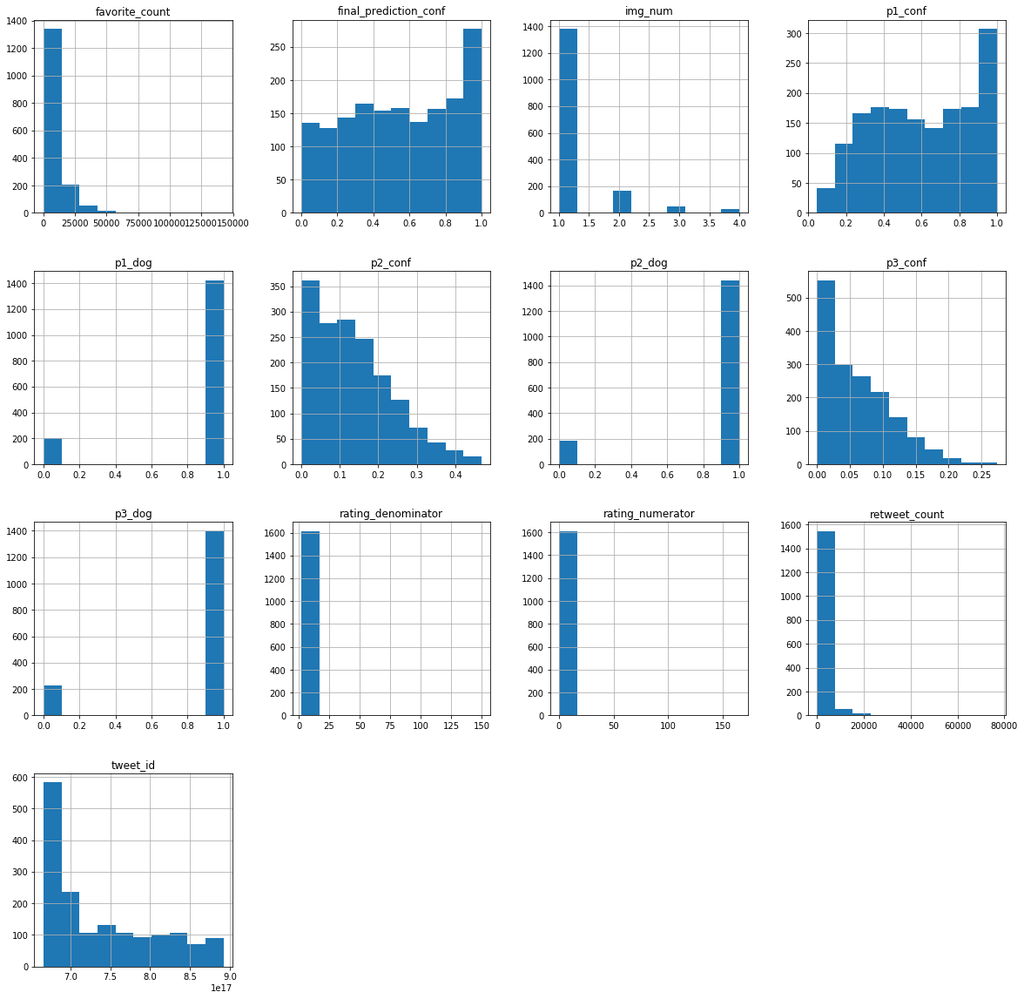

```python
df_all.hist(figsize=(20, 20))
```

Because, I have already created one feature called final_prediction value shows final prection of dogs's breed. I will not explore these variables and I will exclude them before starting the model.

## Investigation of predicted dogs' breed

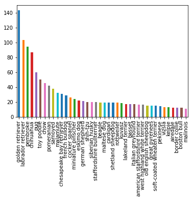

```python
df_all.final_prediction.value_counts().head(40).plot.bar()
```

It can be seen that final_prediction features which includes predicted breeds of dog has so many unique value. Therefore, this graphs gives us great intiution that predicting dog's breed cannot be good model. Instead of predicting it, I can try to understand whether dog's breed retriever or not.

*Define*

Create new feature gives information of whether dog's breed retriever or not. If it is retiever, assign 1 else 0.

*Code*

```python
retriever_flag = []
retriever = ['retriever']

for final_prediction in df_all['final_prediction']:
    # retriever
    if any(map(lambda v:v in retriever, str(final_prediction).split())):
        retriever_flag.append(1)
    else:
        retriever_flag.append(0)

df_all['retriever_flag'] = retriever_flag
```

*Test*

```python
df_all['retriever_flag'].value_counts()
```

```
0    1337
1     288
Name: retriever_flag, dtype: int64
```

## Comparing name and new named column created in the data wrangling part

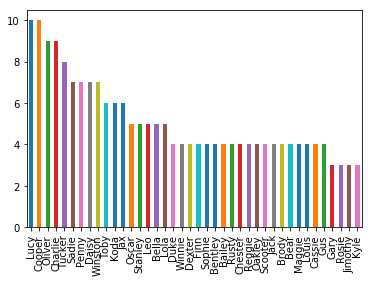

```python
df_all.new_dog_names.value_counts().head(40).plot.bar()
```

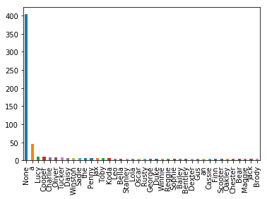

```python
df_all.name.value_counts().head(40).plot.bar()
```

I will drop name coloumn includes old names of dogs due to data quality issue.

## lang column investigation

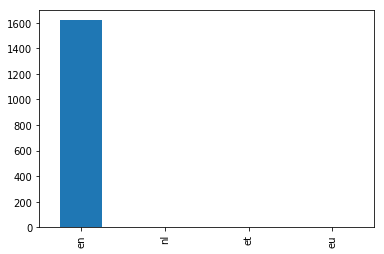

```python
df_all.lang.value_counts().plot.bar()
```

I will drop this feature beacuse there is no information in it.

## source column investigation

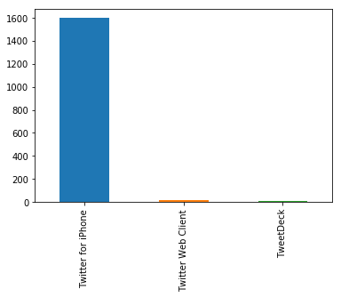

```python
df_all.source.value_counts().plot(kind = 'bar')
```

Most of tweets comes from iphone.

## dog_gender investigation

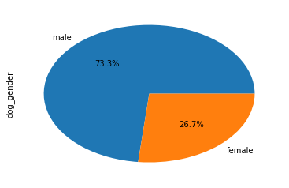

```python
df_all.dog_gender.value_counts().plot(kind = 'pie', autopct='%1.1f%%')
```

%73 of dogs is male according to text included in tweets.

## stages investigation

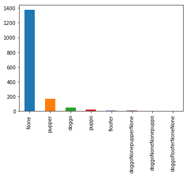

```python
df_all.stage.value_counts().plot.bar()
```

Most of stages of dog information cannot be understanded from text. However, it can be still beneficial to see on modelling stage.

### Multi-variate Exploratory Analysis

In this section, I will investigate dataset with the perceptive of interaction between features.

### Correlation between float features

```
Text(0.5,1,'Correlation Map')
```

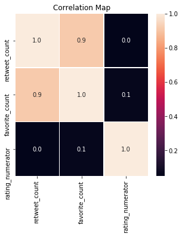

```python
e,ea = plt.subplots(figsize=(5, 5))
sns.heatmap(df_all[['retweet_count', 'favorite_count',
                       'rating_numerator', 'final_prediction']].corr(), annot=True, linewidths=.5, fmt= '.1f',ax=ea)
plt.title('Correlation Map')
```

It can been from correlation map, number of favourite and retweet count are very correlated with each other like expected. Let's look at in more detailed.

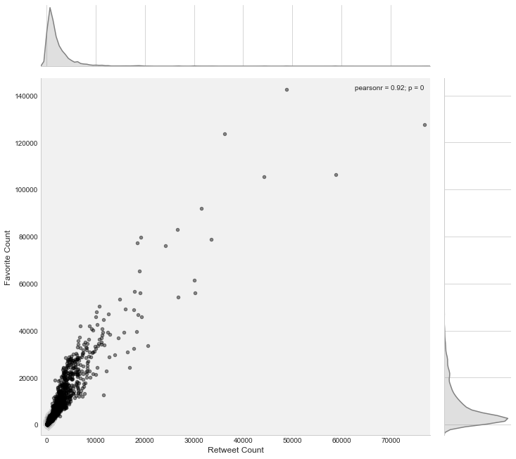

```python
sns.set_style('whitegrid')
g = sns.jointplot(x="retweet_count",
                  y="favorite_count",
                  data=df_all,
                  color="grey",
                  kind="kde",
                  size=10)
g.plot_joint(plt.scatter,
             c="black",
             s=80,
             linewidth=1,
             marker=".",
             alpha=0.45)
g.set_axis_labels("Retweet Count", "Favorite Count",fontsize=12)

g.fig.subplots_adjust(top=0.9)
```

## Top favorited and tweeted url information

```python
top_retweet_url = df_all[df_all.retweet_count == max(df_all.retweet_count)]
top_retweet_url
```

|  | retweet_count | favorite_count | lang | created_at | tweet_id | timestamp | source | text | expanded_urls | rating_numerator | ... | p3 | p3_conf | p3_dog | final_prediction | final_prediction_conf | new_dog_names | dog_gender | date | time | stage |
| --- | --- | --- | --- | --- | --- | --- | --- | --- | --- | --- | --- | --- | --- | --- | --- | --- | --- | --- | --- | --- | --- |
| 651 | 76893 | 127616 | en | Sat Jun 18 18:26:18 +0000 2016 | 7.442348e+17 | 2016-06-18 18:26:18 | Twitter for iPhone | Here's a doggo realizing you can stand in a po... | https://twitter.com/dog_rates/status/744234799... | 13.0 | ... | whippet | 0.018442 | True | labrador retriever | 0.825333 | NaN | NaN | 06-18-2016 | 18:26 | doggo |

1 rows × 34 columns

```python
top_favorite_url = df_all.expanded_urls[df_all.favorite_count == max(df_all.favorite_count)]
top_favorite_url
```

```
273    https://twitter.com/dog_rates/status/822872901...
Name: expanded_urls, dtype: object
```

## Predictive Data Analysis

Analysis has been done on Microsoft Azure Machine Learning studio environment details are given in the word document.